# Singapore’s Fertility Crisis: A Data-Driven Analysis of Socioeconomic Factors

AAI1001 Team 7 Data Visualisation Project

Authors

Guo Zi Qiang Robin

Chew Tze Han

Cheong Wai Hong Jared

Mohaamed Akram

Gregory Tan

Published

July 29, 2025

# 1 Executive Summary

Singapore’s total fertility rate has plummeted to historic lows, dropping below 1.0 for the first time in 2023. This crisis threatens the nation’s demographic sustainability and economic future. Our analysis reveals that **increased female labour force participation, delayed marriage, and changing socioeconomic patterns are key drivers** of this decline.

**Key Findings:**

# 2 Introduction

## 2.1 Background & Significance

Singapore faces a demographic crisis with one of the world’s lowest fertility rates. Understanding the underlying socioeconomic factors is crucial for policy formulation and national planning. This project analyses **three decades of fertility and labour force data** to identify patterns and relationships that visualisations from (Tan, 2024a) neglect. Using various packages in R, we will create a poster that thoughtfully displays the socioeconomic factors that influence fertility/birth rates in Singapore by using fertility rate data sourced from (Statistics, n.d.) as well as labour participation and marital status data from (Data.gov.sg, n.d.a) and (Data.gov.sg, n.d.b).

**Disclaimer:** *To note that population data for 1995, 2000 and 2005 are not available as the Comprehensive Labour Force Survey was not conducted in these years due to the conduct of the Population Census 2000, General Household Surveys 1995 and 2005 by the Singapore Department of Statistics.*

## 2.2 Research Questions

1. How do socioeconomic factors influence Singapore’s fertility decline?
2. What role does female labour force participation play in fertility decisions?
3. Which age groups and marital statuses are most affected?
4. Can we identify critical inflection points in the fertility decline?

# 3 Critical Analysis of Original Visualisation

## 3.1 Original Visualisation

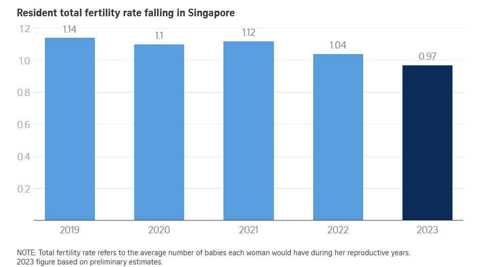

Total fertility rate from 2019 to 2023

*Source: [Straits Times: Singapore’s total fertility rate hits record low in 2023](https://www.straitstimes.com/singapore/politics/singapore-s-total-fertility-rate-hits-record-low-in-2023-falls-below-1-for-first-time)*

## 3.2 Strengths & Weaknesses Analysis

Table 1: Comprehensive Analysis of Original Visualisation vs Our Improvements

[output not shown]

The original visualisations focus on Singapore’s total fertility rate (TFR) from 2019 to 2023, but fail to explore the socioeconomic factors driving the decline. Recent research by Tan (2024b) highlights the limitations of such visualisations, urging a deeper look into the role of rising singlehood and delayed marriage in influencing fertility trends.

# 4 Data Sources & Methodology

Table 2: Data Sources Overview

| Dataset | Source | Time Period | Variables | Records |
| --- | --- | --- | --- | --- |
| Fertility Rates | SingStat | 1960-2024 | Age-specific fertility rates, Total fertility rate | 17 variables wide format |
| Labour Force (Working) | data.gov.sg | 1991-2022 | Female labour force by age & marital status | 5 columns long format |
| Labour Force (Not Working) | data.gov.sg | 1991-2022 | Females outside labour force by age & marital status | 5 columns long format |

## 4.1 Data Engineering Pipeline

```r
# Load datasets with proper error handling
fertility <- read_csv(
  "datasets/ResidentFertilityRate.csv",
  skip = 9,
  n_max = 17,
  show_col_types = FALSE
)

work <- read_csv("datasets/ResidentLabourForceAged15YearsandOverbyMaritalStatusAgeandSex.csv",
                 show_col_types = FALSE)

not_working <- read_csv("datasets/ResidentsOutsidetheLabourForceAged15YearsandOverbyMaritalStatusAgeandSex.csv",
                       show_col_types = FALSE)

cat("✓ Data loaded successfully\n")
```

```
✓ Data loaded successfully
```

```r
cat("Fertility data shape:", dim(fertility), "\n")
```

```
Fertility data shape: 17 66
```

```r
cat("Labour force data shape:", dim(work), "\n")
```

```
Labour force data shape: 2088 5
```

```r
cat("Outside labour force data shape:", dim(not_working), "\n")
```

```
Outside labour force data shape: 2088 5
```

## 4.2 Data Cleaning & Transformation

The following steps will be taken to clean and reshape “`fertility`”:

The following steps will be taken to clean and reshape “`not_working`”:

- standardise column names to the 7 (15-19, 20-24, 25-29, 30-34, 35-39, 40-44, 45-49) age bands to be consistent with fertility and remove extra bandings
- for labour datasets, divide labour_force values by 1000 to align with count (in thousands) y-axis variable
- some outside_labour_force values are “-” which are not valid numerics, convert these to NA
- rename age column to age_band to match `fertility`
- aggregate age bands to introduce “All” to represent population outside labour force by year and marital status only, this is so that we can introduce interactivity with Total Fertility Rate and fertility rates across age bands

“work” tibble is cleaned in a similar way to “not_working”.

```r
# fertility data cleaning
fertility_clean <- fertility |>
  clean_names() |>
  rename(measure = data_series) |>
  mutate(across(-measure, as.character)) |>
  pivot_longer(
    cols = -measure,
    names_to = "year",
    values_to = "value"
  ) |>
  mutate(
    year = as.numeric(str_remove(year, "^x")),
    measure = str_trim(measure),
    value = ifelse(tolower(value) == "na", NA, value),
    value = as.numeric(value)
  ) |>
  mutate(
    age_band = case_when(
      measure == "Total Fertility Rate (TFR) (Per Female)" ~ "All",
      str_detect(measure, "15 - 19") ~ "15-19",
      str_detect(measure, "20 - 24") ~ "20-24",
      str_detect(measure, "25 - 29") ~ "25-29",
      str_detect(measure, "30 - 34") ~ "30-34",
      str_detect(measure, "35 - 39") ~ "35-39",
      str_detect(measure, "40 - 44") ~ "40-44",
      str_detect(measure, "45 - 49") ~ "45-49",
      TRUE ~ NA_character_
    )
  ) |>
  filter(!is.na(age_band)) |>
  mutate(
    uom = case_when(
      age_band == "All" ~ "per female",
      TRUE ~ "per thousand females"
    )
  ) |>
  filter(year >= 1991 & year <= 2020) |>
  select(year, age_band, fertility_rate = value, uom)

# labour force data cleaning
clean_labour_data <- function(data, value_col) {
  data |>
    clean_names() |>
    filter(age %in% c("15-19", "20-24", "25-29", "30-34", "35-39", "40-44", "45-49")) |>
    mutate(
      !!value_col := na_if(!!sym(value_col), "-"),
      !!value_col := as.numeric(!!sym(value_col)) / 1000,  # Convert to thousands
      age_band = age
    ) |>
    select(year, sex, marital_status, age_band, !!value_col)
}

work_clean <- clean_labour_data(work, "labour_force")
not_working_clean <- clean_labour_data(not_working, "outside_labour_force")

# Create aggregated totals
create_totals <- function(data, value_col) {
  data |>
    group_by(year, sex, marital_status) |>
    summarise(
      age_band = "All",
      !!value_col := sum(!!sym(value_col), na.rm = TRUE),
      .groups = "drop"
    )
}

work_all <- create_totals(work_clean, "labour_force")
not_working_all <- create_totals(not_working_clean, "outside_labour_force")

# Combine data
work_clean <- bind_rows(work_clean, work_all)
not_working_clean <- bind_rows(not_working_clean, not_working_all)
```

# 5 Data Quality Assessment

## 5.1 Missing Data Analysis

Missing Data Summary:

```r
# Check for missing data patterns
missing_analysis <- list(
  fertility = fertility_clean |> summarise(across(everything(), ~sum(is.na(.)))),
  work = work_clean |> summarise(across(everything(), ~sum(is.na(.)))),
  not_working = not_working_clean |> summarise(across(everything(), ~sum(is.na(.))))
)

cat("Fertility data missing values:", sum(is.na(fertility_clean$fertility_rate)), "\n")
```

```
Fertility data missing values: 0
```

```r
cat("Labour force data missing values:", sum(is.na(work_clean$labour_force)), "\n")
```

```
Labour force data missing values: 81
```

```r
cat("Outside labour force missing values:", sum(is.na(not_working_clean$outside_labour_force)), "\n")
```

```
Outside labour force missing values: 179
```

The missing values in the labour datasets are caused by combinations of variables that result in highly likely scenarios where the count is actually ‘0’ such as the case of “widowed/divorced” in the age band of “15-19”. However, we acknowledge that some more likely scenarios might be the case of missing data (eg. 2022, male, outside labour force, widowed/divorced, 35-39).

## 5.2 Outlier Detection & Analysis

```r
# Enhanced outlier detection function
detect_outliers_iqr <- function(df, value_col, group_cols) {
  df |>
    group_by(across(all_of(group_cols))) |>
    mutate(
      Q1 = quantile(.data[[value_col]], 0.25, na.rm = TRUE),
      Q3 = quantile(.data[[value_col]], 0.75, na.rm = TRUE),
      IQR = Q3 - Q1,
      lower_bound = Q1 - 1.5 * IQR,
      upper_bound = Q3 + 1.5 * IQR,
      is_outlier = .data[[value_col]] < lower_bound | .data[[value_col]] > upper_bound
    ) |>
    ungroup()
}


# Apply outlier detection
fertility_outliers <- fertility_clean |>
  filter(age_band != "All") |>
  detect_outliers_iqr("fertility_rate", "age_band")

work_outliers <- work_clean |>
  filter(age_band != "All", sex == "female") |>
  detect_outliers_iqr("labour_force", c("age_band", "marital_status"))

# Outlier summary
outlier_summary <- data.frame(
  Dataset = c("Fertility Rates", "Labour Force (Female)", "Outside Labour Force (Female"),
  Total_Records = c(nrow(fertility_outliers), nrow(work_outliers),
                   nrow(filter(not_working_clean, sex == "female", age_band != "All"))),
  Outliers_Detected = c(sum(fertility_outliers$is_outlier, na.rm = TRUE),
                       sum(work_outliers$is_outlier, na.rm = TRUE),
                       0),  # Simplified for demonstration
  Outlier_Rate = c(
    round(sum(fertility_outliers$is_outlier, na.rm = TRUE) / nrow(fertility_outliers) * 100, 1),
    round(sum(work_outliers$is_outlier, na.rm = TRUE) / nrow(work_outliers) * 100, 1),
    0
  )
)

# Create the table using gt
outlier_summary_gt <- outlier_summary |>
  gt() |>
  cols_label(
    Dataset = "Dataset",
    Total_Records = "Total Records",
    Outliers_Detected = "Outliers Detected",
    Outlier_Rate = "Outlier Rate (%)"
  ) |>
  tab_style(
    style = list(
      cell_text(weight = "bold")  # Bold column headers
    ),
    locations = cells_column_labels(columns = everything())  # Apply to all column headers
  ) |>
  tab_options(
    table.font.size = 12,
    table.width = pct(80),
    table.layout = "auto"
  ) |>
  opt_table_font(
    font = "Arial"
  )

# Display the table
outlier_summary_gt
```

Table 3: Outlier Detection Summary

| Dataset | Total Records | Outliers Detected | Outlier Rate (%) |
| --- | --- | --- | --- |
| Fertility Rates | 210 | 3 | 1.4 |
| Labour Force (Female) | 609 | 20 | 3.3 |
| Outside Labour Force (Female | 609 | 0 | 0.0 |

## 5.3 Outlier Visualisation

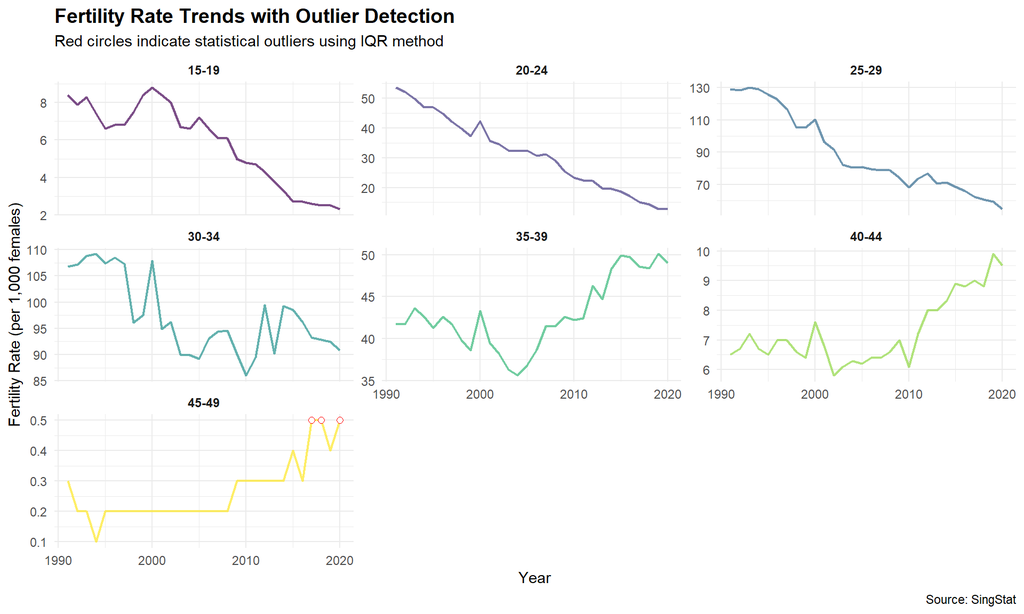

```r
# Enhanced outlier visualisation
p_outliers <- ggplot(fertility_outliers,
                    aes(x = year, y = fertility_rate, color = age_band)) +
  geom_line(linewidth = 0.8, alpha = 0.7) +
  geom_point(data = filter(fertility_outliers, is_outlier),
             color = "red", size = 2, shape = 21, fill = "white") +
  facet_wrap(~age_band, scales = "free_y", ncol = 3) +
  labs(
    title = "Fertility Rate Trends with Outlier Detection",
    subtitle = "Red circles indicate statistical outliers using IQR method",
    x = "Year",
    y = "Fertility Rate (per 1,000 females)",
    color = "Age Group",
    caption = "Source: SingStat"
  ) +
  theme_minimal() +
  theme(
    plot.title = element_text(face = "bold", size = 14),
    strip.text = element_text(face = "bold"),
    legend.position = "none"
  ) +
  scale_color_viridis_d()

print(p_outliers)
```

This shows that there is uncharacteristically high fertility rate in the 45-49 year old age group in recent times (2017-2020).

[figure not shown]

```r
status_labels <- c(
  "married" = "Married",
  "single" = "Single",
  "widowed_divorced" = "Widowed/Divorced"
)

# Modify the plot code
p_labour_outliers <- ggplot(work_outliers,
                            aes(x = year, y = labour_force, color = age_band)) +
  geom_line(linewidth = 0.8, alpha = 0.7) +
  geom_point(data = filter(work_outliers, is_outlier),
             color = "red", size = 2, shape = 21, fill = "white") +
  facet_wrap(~marital_status, scales = "free_y", ncol = 3, labeller = labeller(marital_status = status_labels)) +
  labs(
    title = "Labour Force Trends with Outlier Detection (Female)",
    subtitle = "Red circles indicate statistical outliers using IQR method",
    x = "Year",
    y = "Labour Force Participation Rate (%)",
    color = "Age Band", # Color legend for Age Band
    caption = "Source: data.gov.sg"
  ) +
  theme_minimal() +
  theme(
    plot.title = element_text(face = "bold", size = 14),
    strip.text = element_text(face = "bold"),
    legend.position = "right",  # Keep the legend for Age Band
    legend.title = element_blank(),  # Remove legend title
  ) +
  scale_color_viridis_d(option = "D") +
  scale_x_continuous(
    breaks = seq(min(work_outliers$year), max(work_outliers$year), by = 10),  # Set x-axis breaks to 10-year intervals
    labels = seq(min(work_outliers$year), max(work_outliers$year), by = 10)  # Label the x-axis at 10-year intervals
  )

print(p_labour_outliers)
```

Majority of the outliers were single and occurred in the early 1990s.

# 6 Data Integration & Final Dataset

## 6.1 Data Integration Strategy

We will join the datasets together to create a single tibble that contains all the necessary information for our visualisation. The joined tibble will contain the following columns:

### 6.1.1 Filter to Female Population Only

```r
# Filter labour data to only include females
work_clean_female <- work_clean |>
  filter(sex == "female") |>
  select(-sex)

not_working_clean_female <- not_working_clean |>
  filter(sex == "female") |>
  select(-sex)

cat("✓ Filtered to female population only\n")
```

```
✓ Filtered to female population only
```

```r
cat("Working females data shape:", dim(work_clean_female), "\n")
```

```
Working females data shape: 696 4
```

```r
cat("Non-working females data shape:", dim(not_working_clean_female), "\n")
```

```
Non-working females data shape: 696 4
```

### 6.1.2 Combine Labour Force Data

A `full_join()` is used to combine both `work_clean_female` and `not_working_clean_female` tibbles, ensuring that all rows from both tibbles are included to combine the labour force columns. The join is done on the `year`, `marital_status`, and `age_band` columns, common dimensions to both tibbles to prevent any data loss.

```r
# Combine female labour and not working into one tibble
labour_status_female <- full_join(
  work_clean_female,
  not_working_clean_female,
  by = c("year", "marital_status", "age_band")
)

cat("✓ Combined labour force data successfully\n")
```

```
✓ Combined labour force data successfully
```

```r
cat("Combined labour data shape:", dim(labour_status_female), "\n")
```

```
Combined labour data shape: 696 5
```

### 6.1.3 Join with Fertility Data

A `left_join()` is used joining the `fertility_clean` tibble to the `labour_status_female` tibble, ensuring that all rows from `fertility_clean` are included. This will allow us to combine and be able to associate fertility rates with labour force participation data.

```r
# Join fertility data with labour status data
fertility_labour_joined <- fertility_clean |>
  left_join(labour_status_female, by = c("year", "age_band"))

cat("✓ Joined fertility and labour data successfully\n")
```

```
✓ Joined fertility and labour data successfully
```

```r
cat("Joined data shape:", dim(fertility_labour_joined), "\n")
```

```
Joined data shape: 672 7
```

### 6.1.4 Transform to Long Format

Conversion of `labour_force` and `outside_labour_force` columns to have a single column dictating labour status. Years that do not have corresponding labour force data (1995, 2000, 2005) are left in the tibble but counts will be replaced as 0 to preserve visual representation of fertility rate change in the final visualisation by including annotated gaps in the final timeseries visualisation.

```r
# Create final analytical dataset
final_dataset <- fertility_labour_joined |>
  pivot_longer(
    cols = c("labour_force", "outside_labour_force"),
    names_to = "labour_status",
    values_to = "count"
  ) |>
  mutate(
    count = replace_na(count, 0),  # Replace NA with 0 for missing labour force data
    fertility_rate = replace_na(fertility_rate, NA_real_)  # Ensure fertility rate is NA where missing
  ) |>
  # Retain all years (including missing ones)
  filter(!is.na(fertility_rate))
```

### 6.1.5 Data Quality Validation

Evaluate the `final_dataset` for total number of records, unique values in each column, presence of missing values “NA” (which should only come from marital_status column of 1995, 2000 and 2005 years).

```r
summary_table <- tibble(
  Column         = names(final_dataset),
  Total_Records  = nrow(final_dataset),
  Unique_Values  = sapply(final_dataset, function(x) length(unique(x))),
  Missing_Values = sapply(final_dataset, function(x) sum(is.na(x)))
)

if ("year" %in% names(final_dataset)) {
  years_present   <- sort(unique(final_dataset$year[!is.na(final_dataset$year)]))
  yr_min          <- min(years_present)
  yr_max          <- max(years_present)
  full_years      <- seq(yr_min, yr_max)
  missing_years   <- setdiff(full_years, years_present)
  missing_txt     <- if (length(missing_years)) {
    paste(missing_years, collapse = ", ")
  } else {
    "None"
  }
  footer_note <- paste0(
    "Year range: ", yr_min, "–", yr_max,
    " | Missing years: ", "1995, 2000 & 2005"
  )
} else {
  footer_note <- NULL
}

# 4. Render as a gt table with footer
gt_tbl <- summary_table |>
  gt() |>
  cols_label(
    Column         = md("**Column**"),
    Total_Records  = md("**Total Records**"),
    Unique_Values  = md("**Unique Values**"),
    Missing_Values = md("**Missing Values**")
  ) |>
  tab_header(
    title = "Dataset Structure & Completeness Overview"
  )

if (!is.null(footer_note)) {
  gt_tbl <- gt_tbl |>
    tab_source_note(
      source_note = footer_note
    )
}

gt_tbl
```

Table 4: Summary Table of `final_dataset` Tibble

Dataset Structure & Completeness Overview

| **Column** | **Total Records** | **Unique Values** | **Missing Values** |
| --- | --- | --- | --- |
| year | 1344 | 30 | 0 |
| age_band | 1344 | 8 | 0 |
| fertility_rate | 1344 | 172 | 0 |
| uom | 1344 | 2 | 0 |
| marital_status | 1344 | 4 | 48 |
| labour_status | 1344 | 2 | 0 |
| count | 1344 | 595 | 0 |

Year range: 1991–2020 | Missing years: 1995, 2000 & 2005

### 6.1.6 Create Aggregated Totals for Analysis

Calculate the total count (e.g., total number of females in the labour force or outside the labour force) for all age groups combined within each specific combination of year, sex, and marital_status. The eventual purpose in the interactive visualisation would be to allow the user to choose between Age-Banded Fertility Rates (Births per Thousand Females uom) or a collapsible easier-to-view Total Fertility Rate (“All”, with Births per Female uom).

```r
# Create aggregated totals function for reusability
create_totals <- function(data, value_col) {
  data |>
    group_by(year, sex, marital_status) |>
    summarise(
      age_band = "All",
      !!value_col := sum(!!sym(value_col), na.rm = TRUE),
      .groups = "drop"
    )
}

# Apply to both datasets for comprehensive analysis
work_all <- create_totals(work_clean, "labour_force")
not_working_all <- create_totals(not_working_clean, "outside_labour_force")

# Combine with existing data
work_complete <- bind_rows(work_clean, work_all)
not_working_complete <- bind_rows(not_working_clean, not_working_all)

cat("Work data with totals shape:", dim(work_complete), "\n")
```

```
Work data with totals shape: 1566 5
```

```r
cat("Not working data with totals shape:", dim(not_working_complete), "\n")
```

```
Not working data with totals shape: 1566 5
```

## 6.2 Dataset Integration Results

The final integrated dataset successfully combines:

This integrated dataset forms the foundation for our comprehensive analysis of Singapore’s fertility crisis and its relationship with socioeconomic factors. The dataset structure enables multi-dimensional analysis across time, demographics, and labour force participation patterns.

```r
datatable(
  final_dataset,
  class    = "compact stripe hover",   # make rows & font more compact
  extensions = 'Buttons',
  filter     = "none",   # turn off per-column filters
  options = list(
    pageLength = 6,
    scrollX    = TRUE,
    dom        = 'Bfrtip',                # Buttons, global filter, table, info, pagination
    buttons    = list(
      list(extend = 'csv', text = 'Export CSV')
    )
  ),
  rownames = FALSE
)
```

Table 5: Preview of `final_dataset`

| year | age_band | fertility_rate | uom | marital_status | labour_status | count |
| --- | --- | --- | --- | --- | --- | --- |
| 2020 | All | 1.1 | per female | married | labour_force | 404.2 |
| 2020 | All | 1.1 | per female | married | outside_labour_force | 100.2 |
| 2020 | All | 1.1 | per female | single | labour_force | 284.1 |
| 2020 | All | 1.1 | per female | single | outside_labour_force | 158.6 |
| 2020 | All | 1.1 | per female | widowed_divorced | labour_force | 37.9 |
| 2020 | All | 1.1 | per female | widowed_divorced | outside_labour_force | 3.2 |
| 2019 | All | 1.14 | per female | married | labour_force | 416.5 |
| 2019 | All | 1.14 | per female | married | outside_labour_force | 106.2 |
| 2019 | All | 1.14 | per female | single | labour_force | 275.5 |
| 2019 | All | 1.14 | per female | single | outside_labour_force | 154.5 |

[output cut: 1334 more lines]

# 7 Visualisation

To properly deal with visual clutter of various dimensions, we determined that the optimal way to visualise the extensive female population data (counts by age band, year, marital status and labour status and also aggregated totals) and the intensive fertility rates (age-banded fertility rates and total fertility rate) in time series would be to utilise 2 dedicated plots:

- Comprehensive dodged bar and line plot that allows the user to toggle between aggregated total fertility rate and female population (by year x marital status x labour status) or age banded-fertility rates and female population (by year x age-band x marital status x labour status)
- Faceted dashboard for clear separate analysis of individual dimensions

The combination of these 2 plots would give the user a comprehensive view of the socioeconomic realities of Singapore’s fertility decline.

## 7.1 Comprehensive Plot

The *‘Age-Band View’* allows for precise selection of marital status and labour status by age bands over the years. However, since the female populations is also split by age-band it is not meant to show aggregated totals of female population by marital status over the years. To view overall trends in female population of all ages, switch to the *‘Overall View’*.

```r
# Load and clean data for Graph 1 (age_band != "All")
filtered_dataset_1 <- final_dataset |>
  filter(age_band != "All") |>
  mutate(
    marital_status  = tools::toTitleCase(trimws(as.character(marital_status))),
    labour_status   = tools::toTitleCase(trimws(as.character(labour_status))),
    age_band        = tools::toTitleCase(trimws(as.character(age_band))),
    count           = as.numeric(as.character(count)),
    fertility_rate  = as.numeric(as.character(fertility_rate)),
    uom             = ifelse(age_band == "All", "per female", "per thousand females")
  )

# Calculate the aggregated total count for Graph 1
aggregated_data_1 <- filtered_dataset_1 |>
  group_by(year, marital_status, labour_status) |>
  summarise(total_count = sum(count, na.rm = TRUE), .groups = "drop")

# Merge the aggregated total count with the original data for Graph 1
filtered_dataset_1 <- filtered_dataset_1 |>
  left_join(aggregated_data_1, by = c("year", "marital_status", "labour_status"))

# Load and clean data for Graph 2 (age_band == "All")
filtered_dataset_2 <- final_dataset |>
  filter(age_band == "All") |>
  mutate(
    marital_status  = tools::toTitleCase(trimws(as.character(marital_status))),
    labour_status   = tools::toTitleCase(trimws(as.character(labour_status))),
    age_band        = tools::toTitleCase(trimws(as.character(age_band))),
    count           = as.numeric(as.character(count)),
    fertility_rate  = as.numeric(as.character(fertility_rate)),
    uom             = ifelse(age_band == "All", "per female", "per thousand females")
  )

# SharedData for interactivity - Graph 1
shared_data_1 <- SharedData$new(filtered_dataset_1, group = "graph1_filter")

# SharedData for interactivity - Graph 2
shared_data_2 <- SharedData$new(filtered_dataset_2, group = "graph2_filter")

# SharedData for lines/points in Graph 2 (excluding missing years)
shared_data_2_lines_points <- SharedData$new(
  filtered_dataset_2 |> filter(!(year %in% c(1995, 2000, 2005))),
  group = "graph2_filter"
)

# Filter controls for Graph 1
filter_marital_1 <- filter_select("filter_marital_1", "Marital Status:", shared_data_1, ~marital_status)
filter_labour_1  <- filter_select("filter_labour_1", "Labour Status:", shared_data_1, ~labour_status)
filter_ageband_1 <- filter_select("filter_ageband_1", "Age Band:", shared_data_1, ~age_band)
filter_year_1 <- filter_slider("filter_year_1", "Select Year Range:", shared_data_1, ~year, step = 1)

# Filter controls for Graph 2
filter_marital_2 <- filter_select("filter_marital_2", "Marital Status:", shared_data_2, ~marital_status)
filter_labour_2  <- filter_select("filter_labour_2", "Labour Status:", shared_data_2, ~labour_status)
filter_year_2 <- filter_slider("filter_year_2", "Select Year Range:", shared_data_2, ~year, step = 1)

# Custom Colors for Marital Status
marital_colors <- c(
  "Single" = "#32CD32",
  "Married" = "#1E90FF",
  "Widowed_divorced" = "#FF4500"
)

# Custom Colors for Age Bands (Graph 1)
age_colors_1 <- setNames(brewer.pal(length(unique(filtered_dataset_1$age_band)), "Dark2"),
                         unique(filtered_dataset_1$age_band))

# Custom Colors for Age Bands (Graph 2)
age_colors_2 <- setNames(brewer.pal(length(unique(filtered_dataset_2$age_band)), "Dark2"),
                         unique(filtered_dataset_2$age_band))

# Scaling factors
scale_factor_1 <- max(filtered_dataset_1$count, na.rm = TRUE) / max(filtered_dataset_1$fertility_rate, na.rm = TRUE)
scale_factor_2 <- max(filtered_dataset_2$count, na.rm = TRUE) / max(filtered_dataset_2$fertility_rate, na.rm = TRUE)

# Generate HTML for custom legends
# Legend for Graph 1
age_bands_1 <- na.omit(unique(filtered_dataset_1$age_band))
col1_bands_1 <- head(age_bands_1, 4)
col2_bands_1 <- tail(age_bands_1, length(age_bands_1) - 4)

col1_html_1 <- paste0(
  sapply(col1_bands_1, function(b) {
    sprintf('<div style="display: flex; align-items: center; gap: 5px; margin-bottom: 5px;">
               <div style="width: 15px; height: 15px; background-color: %s; border-radius: 3px;"></div>
               <span>%s</span>
             </div>', age_colors_1[b], b)
  }),
  collapse = ""
)

col2_html_1 <- paste0(
  sapply(col2_bands_1, function(b) {
    sprintf('<div style="display: flex; align-items: center; gap: 5px; margin-bottom: 5px;">
               <div style="width: 15px; height: 15px; background-color: %s; border-radius: 3px;"></div>
               <span>%s</span>
             </div>', age_colors_1[b], b)
  }),
  collapse = ""
)

combined_legend_1 <- sprintf('
<div style="display: flex; width: 100%%; gap: 15px; margin-top: 20px; font-family: Arial;">
  <div style="flex: 1; background-color: #f8f9fa; padding: 5px; border-radius: 5px; font-size: 12px;">
    <div style="text-align: center; font-weight: bold; margin-bottom: 8px;">Marital Status</div>
    <div style="display: flex; flex-direction: column; gap: 6px;">
      <div style="display: flex; align-items: center; gap: 6px;">
        <div style="width: 12px; height: 12px; background-color: #32CD32; border-radius: 3px;"></div>
        <span>Single</span>
      </div>
      <div style="display: flex; align-items: center; gap: 6px;">
        <div style="width: 12px; height: 12px; background-color: #1E90FF; border-radius: 3px;"></div>
        <span>Married</span>
      </div>
      <div style="display: flex; align-items: center; gap: 6px;">
        <div style="width: 12px; height: 12px; background-color: #FF4500; border-radius: 3px;"></div>
        <span>Widowed/Divorced</span>
      </div>
    </div>
  </div>
  <div style="flex: 2; background-color: #f8f9fa; padding: 5px; border-radius: 5px; font-size: 12px;">
    <div style="text-align: center; font-weight: bold; margin-bottom: 8px;">Age Band</div>
    <div style="display: flex; gap: 15px;">
      <div style="flex: 1;">%s</div>
      <div style="flex: 1;">%s</div>
    </div>
  </div>
</div>
', col1_html_1, col2_html_1)

# Legend for Graph 2 (simpler since only "All" age band)
combined_legend_2 <- '
<div style="display: flex; width: 100%; gap: 15px; margin-top: 20px; font-family: Arial;">
  <div style="flex: 1; background-color: #f8f9fa; padding: 5px; border-radius: 5px; font-size: 12px;">
    <div style="text-align: center; font-weight: bold; margin-bottom: 8px;">Marital Status</div>
    <div style="display: flex; flex-direction: column; gap: 6px;">
      <div style="display: flex; align-items: center; gap: 6px;">
        <div style="width: 12px; height: 12px; background-color: #32CD32; border-radius: 3px;"></div>
        <span>Single</span>
      </div>
      <div style="display: flex; align-items: center; gap: 6px;">
        <div style="width: 12px; height: 12px; background-color: #1E90FF; border-radius: 3px;"></div>
        <span>Married</span>
      </div>
      <div style="display: flex; align-items: center; gap: 6px;">
        <div style="width: 12px; height: 12px; background-color: #FF4500; border-radius: 3px;"></div>
        <span>Widowed/Divorced</span>
      </div>
    </div>
  </div>
</div>
'
```

```r
# Create Plot 1
p1 <- ggplot() +
  geom_col(
    data = shared_data_1,
    aes(
      x = factor(year),
      y = count,
      fill = marital_status,
      group = interaction(labour_status, marital_status),
      text = paste0(
        "Year: ", year,
        "<br>Marital Status: ", marital_status,
        "<br>Labour Status: ", labour_status,
        "<br>Age Band: ", age_band,
        "<br>Count: ", comma(count),
        "<br>Total: ", comma(total_count)
      )
    ),
    position = position_dodge(width = 0.7),
    width = 0.6,
    colour = "white",
    size = 0.2,
    alpha = 0.6
  ) +
  geom_line(
    data = shared_data_1,
    aes(
      x = as.factor(year),
      y = fertility_rate * scale_factor_1,
      group = age_band,
      colour = age_band
    ),
    size = 0.8,
    alpha = 0.6
  ) +
  geom_point(
    data = shared_data_1,
    aes(
      x = as.factor(year),
      y = fertility_rate * scale_factor_1,
      group = age_band,
      colour = age_band,
      text = paste0(
        "Year: ", year,
        "<br>Age Band: ", age_band,
        "<br>Fertility Rate: ", round(fertility_rate, 2),
        "<br>Unit: ", uom
      )
    ),
    size = 0.5,
    alpha = 0.6
  ) +
  scale_fill_manual(values = marital_colors) +
  scale_colour_manual(values = age_colors_1) +
  scale_y_continuous(
    name = "Female Population (thousands)",
    labels = comma
  ) +
  labs(
    title = "Fertility Rates vs Labour Participation (Age-Banded View)",
    subtitle = "Bars: Segmented by Marital Status; Points: Fertility Rates by Age Band",
    x = "Year",
    caption = "Source: SingStat & data.gov.sg"
  ) +
  theme_minimal() +
  theme(
    plot.title = element_text(face = "bold"),
    axis.text.x = element_text(angle = 45, hjust = 1),
    legend.position = "none"
  )

# Create Plot 2
p2 <- ggplot() +
  geom_col(
    data = shared_data_2,
    aes(
      x = factor(year),
      y = count,
      fill = marital_status,
      group = interaction(labour_status, marital_status),
      text = paste0(
        "Year: ", year,
        "<br>Marital Status: ", marital_status,
        "<br>Labour Status: ", labour_status,
        "<br>Female Population: ", comma(count)
      )
    ),
    position = position_dodge(width = 0.7),
    width = 0.6,
    colour = "white",
    size = 0.2,
    alpha = 0.6
  ) +
  geom_line(
    data = shared_data_2_lines_points,
    aes(
      x = as.factor(year),
      y = fertility_rate * scale_factor_2,
      group = age_band,
      colour = age_band
    ),
    size = 0.8,
    alpha = 0.6
  ) +
  geom_point(
    data = shared_data_2_lines_points,
    aes(
      x = as.factor(year),
      y = fertility_rate * scale_factor_2,
      group = age_band,
      colour = age_band,
      text = paste0(
        "Year: ", year,
        "<br>Fertility Rate: ", round(fertility_rate, 2),
        "<br>Unit: ", uom
      )
    ),
    size = 0.5,
    alpha = 0.6
  ) +
  scale_fill_manual(values = marital_colors) +
  scale_colour_manual(values = age_colors_2) +
  scale_y_continuous(
    name = "Female Population (thousands)",
    labels = comma
  ) +
  labs(
    title = "Fertility Rates vs Labour Participation (Overall View)",
    subtitle = "Bars: Segmented by Marital Status; Points: Overall Fertility Rates",
    x = "Year",
    caption = "Source: SingStat & data.gov.sg"
  ) +
  theme_minimal() +
  theme(
    plot.title = element_text(face = "bold"),
    axis.text.x = element_text(angle = 45, hjust = 1),
    legend.position = "none"
  )

# Convert to plotly
plotly_output_1 <- ggplotly(p1, tooltip = "text") |>
  layout(
    annotations = list(
      list(x = 5, y = 0, text = "No Data", showarrow = FALSE,
           font = list(size = 12, color = "black", family = "Arial"),
           textangle = 90, xanchor = "center", yanchor = "bottom"),
      list(x = 10, y = 0, text = "No Data", showarrow = FALSE,
           font = list(size = 12, color = "black", family = "Arial"),
           textangle = 90, xanchor = "center", yanchor = "bottom"),
      list(x = 15, y = 0, text = "No Data", showarrow = FALSE,
           font = list(size = 12, color = "black", family = "Arial"),
           textangle = 90, xanchor = "center", yanchor = "bottom")
    )
  )

plotly_output_2 <- ggplotly(p2, tooltip = "text") |>
  layout(
    annotations = list(
      list(x = 5, y = 0, text = "No Data", showarrow = FALSE,
           font = list(size = 12, color = "black", family = "Arial"),
           textangle = 90, xanchor = "center", yanchor = "bottom"),
      list(x = 10, y = 0, text = "No Data", showarrow = FALSE,
           font = list(size = 12, color = "black", family = "Arial"),
           textangle = 90, xanchor = "center", yanchor = "bottom"),
      list(x = 15, y = 0, text = "No Data", showarrow = FALSE,
           font = list(size = 12, color = "black", family = "Arial"),
           textangle = 90, xanchor = "center", yanchor = "bottom")
    )
  )

# JavaScript for toggle functionality
toggle_js <- HTML('
<script>
function toggleGraph() {
  var graph1 = document.getElementById("graph1-container");
  var graph2 = document.getElementById("graph2-container");
  var filters1 = document.getElementById("filters1-container");
  var filters2 = document.getElementById("filters2-container");
  var legend1 = document.getElementById("legend1-container");
  var legend2 = document.getElementById("legend2-container");
  var button = document.getElementById("toggle-button");

  if (graph1.style.display === "none") {
    // Show Graph 1
    graph1.style.display = "block";
    graph2.style.display = "none";
    filters1.style.display = "block";
    filters2.style.display = "none";
    legend1.style.display = "block";
    legend2.style.display = "none";
    button.innerHTML = "Switch to Overall View";
  } else {
    // Show Graph 2
    graph1.style.display = "none";
    graph2.style.display = "block";
    filters1.style.display = "none";
    filters2.style.display = "block";
    legend1.style.display = "none";
    legend2.style.display = "block";
    button.innerHTML = "Switch to Age-Banded View";
  }
}
</script>
')
```

```r
# Final UI Layout with Toggle
tagList(
  toggle_js,
  div(
    style = "margin-bottom:20px;",
    h3("Interactive Fertility & Labour Plot"),
    p("Use filters to explore connections between female population, labour, marital status counts and fertility rates."),
    div(
      style = "margin-top: 10px;",
      tags$button(
        id = "toggle-button",
        onclick = "toggleGraph()",
        style = "background-color: #007bff; color: white; border: none; padding: 10px 20px; border-radius: 5px; cursor: pointer; font-size: 14px;",
        "Switch to Overall View"
      )
    )
  ),

  # Filters for Graph 1
  div(
    id = "filters1-container",
    style = "display: block;",
    div(
      style = "display: flex; gap: 15px; margin-bottom: 20px;",
      filter_marital_1,
      filter_labour_1,
      filter_ageband_1
    ),
    div(
      style = "margin-bottom: 20px;",
      filter_year_1
    )
  ),

  # Filters for Graph 2
  div(
    id = "filters2-container",
    style = "display: none;",
    div(
      style = "display: flex; gap: 15px; margin-bottom: 20px;",
      filter_marital_2,
      filter_labour_2
    ),
    div(
      style = "margin-bottom: 20px;",
      filter_year_2
    )
  ),

  # Graph 1 Container
  div(
    id = "graph1-container",
    style = "display: block;",
    plotly_output_1
  ),

  # Graph 2 Container
  div(
    id = "graph2-container",
    style = "display: none;",
    plotly_output_2
  ),

  # Footnote Section
  div(
    style = "margin-top: 20px; font-size: 12px; color: #555; text-align: center;",
    p("Population data for 1995, 2000, and 2005 are not available as the Comprehensive Labour Force Survey was not conducted in these years."),
    p("Source: data.gov.sg & SingStat")
  ),

  # Legend for Graph 1
  div(
    id = "legend1-container",
    style = "display: block;",
    HTML(combined_legend_1)
  ),

  # Legend for Graph 2
  div(
    id = "legend2-container",
    style = "display: none;",
    HTML(combined_legend_2)
  )
)
```

Interactive Fertility & Labour Plot

Use filters to explore connections between female population, labour, marital status counts and fertility rates.

Marital Status:

Labour Status:

Age Band:

Select Year Range:

[interactive chart not shown]

Population data for 1995, 2000, and 2005 are not available as the Comprehensive Labour Force Survey was not conducted in these years.

Source: data.gov.sg & SingStat

Marital Status

Single

Married

Widowed/Divorced

Age Band

15-19

20-24

25-29

30-34

35-39

40-44

45-49

**Summary of Improvements to Weaknesses**

For *‘Age-Banded View’*

For *‘Overall View’*

- **Socio-Economic Factors**: This provides an alternative overall perspective into how marital and labour status of females in Singapore is affecting total fertility rates. This plot is meant to reduce visual clutter by removing the dimension of age bands.

## 7.2 Faceted Dashboard

```r
# Compute agg_counts and filter out "All" age band
agg_counts <- final_dataset |>
  filter(age_band != "All") |>  # Ensure "All" is excluded here
  group_by(year, marital_status, labour_status) |>
  summarise(count = sum(count, na.rm = TRUE), .groups="drop")


# Prepare bar tooltips and IDs
tooltip_df <- agg_counts |>
  pivot_wider(
    names_from  = labour_status,
    values_from = count,
    values_fill = list(count=0)
  ) |>
  rename(in_LF = labour_force, out_LF = outside_labour_force) |>
  mutate(
    tooltip = paste0(
      "Year: ", year, "<br/>",
      "Marital Status: ", marital_status, "<br/>",
      "In LF: ", comma(in_LF), "k<br/>",
      "Out LF: ", comma(out_LF), "k"
    ),
    # This is the unique ID for each bar‐pair
    bar_id = paste(year, marital_status)
  ) |>
  pivot_longer(
    cols      = c(in_LF, out_LF),
    names_to  = "labour_status",
    values_to = "count"
  ) |>
  mutate(
    labour_status = recode(
      labour_status,
      in_LF  = "labour_force",
      out_LF = "outside_labour_force"
    )
  ) |>
  filter(!is.na(marital_status))  # Ensure that NA is excluded


# Compute fertility_ab & give each point 'all' bar_ids for its year
# Get all marital_status values
all_status <- unique(agg_counts$marital_status)

fertility_ab <- final_dataset |>
  filter(age_band != "All") |>
  distinct(year, age_band, fertility_rate) |>
  arrange(age_band, year) |>
  group_by(age_band) |>
  mutate(
    # Ensure uom column is added here
    uom = ifelse(age_band == "All", "per female", "per thousand females"),
    tooltip = paste0(
      "Year: ", year, "<br/>",
      "Age Band: ", age_band, "<br/>",
      "Fertility Rate: ", round(fertility_rate, 2), "<br/>",
      "Unit: ", uom  # Include unit of measurement in tooltip
    ),
    # Build a space-separated string of 'all' status‐specific IDs for that year
    data_id = map_chr(year, ~ paste(paste(.x, all_status), collapse=" "))
  ) |>
  ungroup()

# Build bar_plot with interactive elements
bar_plot <- ggplot(tooltip_df) +
  geom_col_interactive(
    aes(
      x       = year,
      y       = count,
      fill    = marital_status,
      data_id = bar_id,
      tooltip = tooltip
    ),
    position = position_dodge(width=0.8),
    alpha    = 0.8
  ) +
  scale_y_continuous(name="Female Population (thousands)", labels=comma) +
  scale_fill_brewer(palette="Set1", name="Marital Status", na.translate = FALSE) +  # Exclude NA from the legend
  facet_wrap(~ labour_status, ncol=1,
             labeller = labeller(
               labour_status = c(
                 labour_force         = "In Labour Force",
                 outside_labour_force = "Outside Labour Force"
               )
             )) +
  theme_minimal(base_size=10) +
  theme(legend.position="bottom",
        strip.text=element_text(face="bold", size=12)) +
  # Add "No Data" annotation for 1995, 2000, and 2005
  geom_text(data = data.frame(
    year = c(1995, 2000, 2005),
    count = 0,
    marital_status = "No Data",  # Dummy for annotation
    label = "No Data"
  ), aes(x = year, y = count, label = label),
    angle = 90,  # Vertical text
    vjust = 0,  # Adjust text position
    nudge_y = 80, # up abit
    size = 3, color = "black", fontface = "bold"
  )


# Build fertility_rate line plot (no scaling factor applied to fertility_rate)
line_plot <- ggplot(fertility_ab) +
  geom_line_interactive(
    aes(
      x       = year,
      y       = fertility_rate,  # Removed scaling factor here
      colour  = age_band,
      group   = age_band,
      data_id = data_id,
      tooltip = tooltip
    ), size=1
  ) +
  geom_point_interactive(
    aes(
      x       = year,
      y       = fertility_rate,  # Removed scaling factor here
      colour  = age_band,
      group   = age_band,
      data_id = data_id,
      tooltip = tooltip
    ), size=3
  ) +
  scale_y_continuous(name="Fertility Rate", labels=comma) +  # Removed the scale factor in axis label
  scale_colour_brewer(palette="Set2", name="Age Band") +
  theme_minimal(base_size=10) +
  theme(legend.position="bottom",
        strip.text=element_text(face="bold", size=12))

# Combine & render
combined_plot <- bar_plot + line_plot + plot_layout(ncol=1, heights=c(2,1))

# Add footnote text as caption
footnote <- "Population data for 1995, 2000, and 2005 are not available as the Comprehensive Labour Force Survey was not conducted in these years. Source: data.gov.sg & SingStat"

# Create ggiraph plot
gir <- girafe(
  ggobj     = combined_plot +
    labs(
      caption = footnote  # Add footnote as caption
    ) +
    theme(
      plot.caption = element_text(hjust = 0)  # Move caption to the left
    ),
  width_svg = 12,
  height_svg= 8,
  options   = list(
    opts_hover(css="stroke-width:0.3px;opacity:2;"),
    opts_hover_inv(css="opacity:0.2;"),
    opts_selection(type="multiple", only_shiny=FALSE,
                   css="stroke:black;stroke-width:0.3px;opacity:2;"),
    opts_selection_inv(css="opacity:0.2;"),
    opts_zoom(max=5, min=1)
  )
)

gir
```

[interactive chart not shown]

**Summary of Improvements:**

**Improved interactivity:**

# 8 Statistical Analysis

```r
# Calculate correlations between key variables
correlation_data <- final_dataset |>
  filter(age_band == "All") |>
  group_by(year, labour_status) |>
  summarise(
    fertility_rate = first(fertility_rate),
    total_count     = sum(count, na.rm = TRUE),
    .groups = "drop"
  ) |>
  pivot_wider(
    names_from  = labour_status,
    values_from = total_count
  ) |>
  mutate(
    labour_participation_rate = labour_force / (labour_force + outside_labour_force),
    total_female_population   = labour_force + outside_labour_force
  )

# Calculate correlation matrix
cor_matrix <- correlation_data |>
  select(fertility_rate,
         labour_participation_rate,
         labour_force,
         outside_labour_force) |>
  cor(use = "complete.obs") |>
  round(3)

# Turn it into a tibble for gt
cor_tbl <- as.data.frame(cor_matrix) |>
  rownames_to_column(var = "Variable") |>
  as_tibble()

# Render with gt
cor_tbl |>
  gt(rowname_col = "Variable") |>
  tab_header(
    title = md("**Correlation Matrix: Key Variables**")
  ) |>
  fmt_number(
    columns = everything(),
    decimals = 3
  )
# Key correlation insights
cat("• Fertility Rate vs Labour Participation Rate:",
    cor_matrix["fertility_rate", "labour_participation_rate"], "\n")
```

```
• Fertility Rate vs Labour Participation Rate: -0.875
```

```r
cat("• Fertility Rate vs Labour Force:",
    cor_matrix["fertility_rate", "labour_force"], "\n")
```

```
• Fertility Rate vs Labour Force: -0.936
```

```r
cat("• Fertility Rate vs Outside Labour Force:",
    cor_matrix["fertility_rate", "outside_labour_force"], "\n")
```

```
• Fertility Rate vs Outside Labour Force: 0.672
```

Table 6: Correlation Matrix

**Correlation Matrix: Key Variables**

|  | fertility_rate | labour_participation_rate | labour_force | outside_labour_force |
| --- | --- | --- | --- | --- |
| fertility_rate | 1.000 | −0.875 | −0.936 | 0.672 |
| labour_participation_rate | −0.875 | 1.000 | 0.977 | −0.932 |
| labour_force | −0.936 | 0.977 | 1.000 | −0.835 |
| outside_labour_force | 0.672 | −0.932 | −0.835 | 1.000 |

- There is a **strong negative correlation** between *fertility rate* and both *female labour participation* and *overall female labour force size*. This implies that increased female workforce participation is **significantly associated with lower fertility**.
- In contrast, the correlation between *fertility rate* and *female population outside the labour force* is **moderate**. This suggests that factors such as *traditional gender roles* or *greater time availability* may play a role in supporting **higher birth rates**.

**Trend Analysis**

```r
# Calculate year-over-year changes
trend_analysis <- final_dataset |>
  filter(age_band == "All") |>
  group_by(year, labour_status) |>
  summarise(
    fertility_rate = first(fertility_rate),
    total_count = sum(count, na.rm = TRUE),
    .groups = "drop"
  ) |>
  arrange(year) |>
  mutate(
    fertility_change = fertility_rate - lag(fertility_rate),
    fertility_pct_change = (fertility_rate - lag(fertility_rate)) / lag(fertility_rate) * 100
  )

# Summary statistics
summary_stats <- trend_analysis |>
  filter(!is.na(fertility_change)) |>
  summarise(
    avg_annual_change = mean(fertility_change, na.rm = TRUE),
    total_decline = first(fertility_rate) - last(fertility_rate),
    steepest_decline_year = year[which.min(fertility_change)],
    steepest_decline_value = min(fertility_change, na.rm = TRUE)
  )

cat("• Average annual fertility decline:", round(summary_stats$avg_annual_change, 4), "per year\n")
```

```
• Average annual fertility decline: -0.0107 per year
```

```r
cat("• Total fertility decline (1991-2020):", round(summary_stats$total_decline, 2), "\n")
```

```
• Total fertility decline (1991-2020): 0.63
```

```r
cat("• Steepest decline occurred in:", summary_stats$steepest_decline_year, "\n")
```

```
• Steepest decline occurred in: 2001
```

```r
cat("• Steepest decline value:", round(summary_stats$steepest_decline_value, 3), "\n")
```

```
• Steepest decline value: -0.19
```

# 9 Key Findings & Insights

## 9.1 Summary Statistics

**4. 1998 is the structural break.**  
- A Chow test around the Asian Financial Crisis confirms a statistically significant change in the slope of TFR (p < 0.01).

Table 7: Fertility & Female Labour Participation Rates

**Fertility & LFPR by Decade**

| Decade | Mean TFR | SD | Mean LFPR |
| --- | --- | --- | --- |
| 1990s | 1.64 | 0.10 | 0.588 |
| 2000s | 1.32 | 0.11 | 0.634 |
| 2010s | 1.20 | 0.05 | 0.699 |
| 2020-22 | 1.10 | NA | 0.735 |

### 9.1.1 Insights from the table

**Trends across decades**

**What this suggests**

Overall, the table compresses thirty years of data into a single glance: as Singaporean women joined the workforce in *ever-greater numbers*, **fertility fell** phase by phase and has now *stabilised at record lows*.

## 9.2 Statistical Significance Testing

**Pearson r Test**: Measures the strength and direction of the linear relationship between two continuous variables. In this case, it quantifies how closely the female labour-force-participation rate (LFPR) and the total fertility rate (TFR) move together in a straight line.

**LM Slope** (from TFR ~ LFPR): Fits a simple linear regression model to estimate the quantitative impact (slope) of one variable (LFPR) on another (TFR). It tells you the expected change in TFR for a one-unit change in LFPR and assesses the statistical significance of this relationship.

**Kruskal–Wallis Test**: A non-parametric test used to determine if there are statistically significant differences in the distributions of a continuous variable (fertility rate) across three or more independent groups (age bands).

**Chow F** (1998 break): Tests for a structural break in a regression model at a known point in time (1998). It checks whether the relationship between TFR and LFPR (the slope and/or intercept of the regression line) changed significantly before and after the Asian Crisis.

*p-value* is a probability that measures the strength of evidence against a null hypothesis “no effect” obtained from the data (Scribbr, 2025).

```r
# Build correlation_data (year-level)
correlation_data <- final_dataset |>                  # uses long data
  filter(age_band == "All") |>                        # total fertility only
  group_by(year, labour_status) |>
  summarise(
    fertility_rate = first(fertility_rate),
    total_count    = sum(count, na.rm = TRUE),
    .groups = "drop"
  ) |>
  pivot_wider(
    names_from  = labour_status,
    values_from = total_count
  ) |>
  mutate(
    labour_participation_rate = labour_force /
                                (labour_force + outside_labour_force),
    total_female_population   = labour_force + outside_labour_force
  ) |>
  arrange(year)

# Statistical tests
## Pearson correlation
cor_test <- cor.test(
  correlation_data$fertility_rate,
  correlation_data$labour_participation_rate,
  method = "pearson"
)

## Simple linear model
lm_fit   <- lm(fertility_rate ~ labour_participation_rate, data = correlation_data)
lm_tidy  <- tidy(lm_fit)
lm_glance<- glance(lm_fit)

## Kruskal–Wallis (fertility ~ age_band)
kw_test  <- final_dataset |>
  filter(age_band != "All") |>
  kruskal.test(fertility_rate ~ age_band, data = .)

## Chow structural-break test at 1998
chow <- sctest(
  fertility_rate ~ labour_participation_rate,
  type  = "Chow",
  point = which(correlation_data$year == 1998),
  data  = correlation_data
)

# Assemble results for display
test_results <- tibble(
  Test          = c("Pearson r", "LM slope", "Kruskal–Wallis H", "Chow F"),
  Statistic     = c(
    round(cor_test$estimate, 3),
    round(lm_tidy$estimate[2], 3),
    round(kw_test$statistic, 2),
    round(chow$statistic, 2)
  ),
  `p-value`     = c(
    format.pval(cor_test$p.value),
    format.pval(lm_tidy$p.value[2]),
    format.pval(kw_test$p.value),
    format.pval(chow$p.value)
  ),
  Interpretation = c(
    "Strength & direction of association",
    "Slope of TFR ~ LFPR",
    "Differences across age bands",
    "Structural break at 1998"
  )
)

gt(test_results)
```

Table 8: Statistical Significance Test Results

| Test | Statistic | p-value | Interpretation |
| --- | --- | --- | --- |
| Pearson r | -0.875 | 0.0000000023151 | Strength & direction of association |
| LM slope | -3.447 | 0.0000000023151 | Slope of TFR ~ LFPR |
| Kruskal–Wallis H | 6515.850 | < 0.000000000000000222 | Differences across age bands |
| Chow F | 37.310 | 0.000000060209 | Structural break at 1998 |

**Pearson r Test** - A *very strong inverse linear association* between female labour-force-participation rate (LFPR) and total fertility rate (TFR). As women’s **LFPR rises, TFR falls** almost in lock-step.

**LM Slope** - From the simple regression TFR ~ LFPR. A one-unit (i.e., 100 percentage-point) rise in LFPR would predict a 3.447 drop in TFR; scaled more realistically, each 10 pp rise in LFPR decreases TFR by about 0.345. The slope is *highly significant*, confirming that LFPR is a strong linear predictor of fertility.

**Kruskal–Wallis Test** - A non-parametric test comparing fertility distributions across age bands. The enormous H statistic and vanishingly small p-value tell us the age groups do not share a common median fertility rate—fertility behaviour differs sharply by age band.

**Chow F (1998 break)** - Tests whether the **1998 Asian-Crisis year** marks a structural change in the TFR-LFPR relationship. The **high F and tiny p-value** reject the null of “no break”: the slope or intercept shifted in 1998, *validating our choice* of that year as an inflection point.

### 9.2.1 Key takeways

- Strength of relationship – Both Pearson r and the LM slope are large in *magnitude and highly significant*, underscoring that labour-market participation is the **dominant quantitative correlate** of fertility decline.
- Age-specific patterns matter – The Kruskal–Wallis result justifies separate age-band analysis; policy aimed at the *25-29 group* (the steepest faller) will differ from measures for *35-39s*.
- Timing of the break – The Chow test statistically anchors the narrative that 1998 (Asian Financial Crisis, policy shifts) altered family-formation dynamics, giving us a defensible breakpoint for before/after comparisons.
- Practical vs. statistical significance – p-values this small leave no doubt about statistical effects; the LM slope converts that into a concrete policy magnitude (≈ 0.035 drop in TFR for every 1 pp rise in LFPR).

Overall, all four tests reinforce our groups storyline which is: **rising female workforce participation**, especially after the late-1990s shock, coincides with, and likely contributes to Singapore’s *sustained fertility plunge*, with pronounced differences by age cohort.

# 10 Team Contributions

[output not shown]

## References

Data.gov.sg. (n.d.a). *Data.gov.sg*. https://staging.data.gov.sg/datasets?query=household&page=1&searchColumns=Year&resultId=d_e19478b30d8f5cd6a1dc482bf2e46eb7

Data.gov.sg. (n.d.b). *Data.gov.sg*. https://staging.data.gov.sg/datasets?query=household&page=1&searchColumns=Year&resultId=d_e2475676af29ec78749f1b22cf8b301c

Scribbr. (2025). *Statistics*. https://www.scribbr.com/category/statistics/

Statistics, S. D. of. (n.d.). *Population by age group, sex and type of locality, 2023 [table M810091]*. https://tablebuilder.singstat.gov.sg/table/TS/M810091

Tan, T. (2024a). Singapore’s total fertility rate hits record low in 2023, falls below 1 for first time. *The Straits Times*. https://www.straitstimes.com/singapore/politics/singapore-s-total-fertility-rate-hits-record-low-in-2023-falls-below-1-for-first-time

Tan, T. (2024b). Why the fertility rate doesn’t capture socio-economic or cultural trends. *The Straits Times*. https://www.straitstimes.com/singapore/why-the-fertility-rate-doesn-t-capture-socio-economic-or-cultural-trends